# Mapping the evidence with R

R practical — heat maps and cross-tabulations for systematic maps

Damien Beillouin

CIRAD, UPR HortSys

## Learning objectives

By the end of this practical, you will be able to:

1. **Count studies, not rows**, when describing an evidence base.
2. Build an **evidence heat map** that shows clusters **and gaps**.
3. **Cross a third variable** from your codebook (organisms, validity…).
4. Say what an evidence map **can and cannot** tell you.

## From codebook to map

This morning you designed a **codebook**. Each coded variable can become an **axis** of a map.

Today’s data: a published systematic map on **diversified farming and biodiversity** (Jones et al. 2021).

- **237** studies · **4,076** comparisons
- **48** countries · 1986–2021
- 105 coded columns in the full database (32 kept for today): practice, comparator, taxon, functional group, validity…

Our question **Where is the evidence — and where is it missing —** on the effects of farm diversification on biodiversity?

Coding shapes the map The published dictionary lists “cover crop”; the data contain none. The data contain “Associated plant species”; the dictionary does not define it.

## Quick quiz

Show of hands

The dataset has **360 rows** from 1992. How many **studies** is that?

- 360
- About 36
- **2**

One study can report dozens of comparisons (taxa, sites, dates). **Rows are not studies — and they are not independent.** Count with `n_distinct(study_id)`.

## Same data, two maps

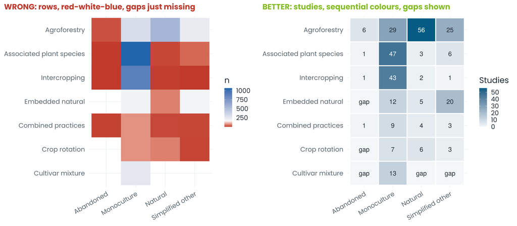

## What an evidence map tells you — and what it does not

It tells you

- **Where** evidence accumulates (clusters)
- **Where** it is missing (gaps)
- **How** it was produced (designs, metrics, validity)
- Whether a **meta-analysis** is feasible, and on what

It does not tell you

- **Whether** a practice works, or how much
- Whether results are **consistent**
- Whether a gap is a **priority** (it may be agronomically irrelevant)

**Many studies ≠ strong effect.** Do not “vote count”.

Source: James et al. (2016); Collaboration for Environmental Evidence (2022).

## Your 30 minutes

| Time | Task | Format |
| --- | --- | --- |
| 14:08 | Open the pack, load the data, count studies | Alone |
| 14:13 | **Exercise 1** — first evidence map (fill the `___`) | Alone |
| 14:25 | **Exercise 2** — add a third dimension: *organisms* **or** *validity* | Pairs |
| 14:35 | 2–3 pairs show their map | All |
| Bonus | Where (world map) and when (cumulative curves) | Later |

Open **`meta_analysis_course.Rproj`** (the course kit), then **`td_evidence_map.R`**. Instructions and folded solutions: **the practical web page**.

## Key messages

1. **Count studies, not rows** — rows are non-independent comparisons.
2. **Show the zeros**: in an evidence map, the gap *is* the result.
3. **Sequential colours and numbers in tiles**: readable by everyone.
4. **A map describes the evidence; it does not say what works.** Your codebook sets its axes.

## In the online notebook

Each point of this session developed further, with the same data, more pitfalls and exercises with solutions:

- [The running example and first data checks](https://literaturesynthesis.github.io/notebook/chapters/running-example.html)
- [Evidence maps: heat maps, gaps and a third dimension](https://literaturesynthesis.github.io/notebook/chapters/evidence-maps.html)
- [Temporal analyses](https://literaturesynthesis.github.io/notebook/chapters/temporal-analyses.html)
- [Spatial analyses](https://literaturesynthesis.github.io/notebook/chapters/spatial-analyses.html)

**literaturesynthesis.github.io/notebook**

## References

Collaboration for Environmental Evidence. 2022. [Guidelines and standards for evidence synthesis in environmental management. Version 5.1](https://environmentalevidence.org/information-for-authors/). (A. S. Pullin, G. K. Frampton, B. Livoreil, and G. Petrokofsky, Eds.). Collaboration for Environmental Evidence.

James, K. L., N. P. Randall, and N. R. Haddaway. 2016. [A methodology for systematic mapping in environmental sciences](https://doi.org/10.1186/s13750-016-0059-6). Environmental Evidence 5:7.

Jones, S. K., A. C. Sánchez, S. D. Juventia, and N. Estrada-Carmona. 2021. [A global database of diversified farming effects on biodiversity and yield](https://doi.org/10.1038/s41597-021-01000-y). Scientific Data 8:212.